# SpatialEconLab

Vought

November 15, 2021

## SISS Lab for Monday, November 22, 2021

# Lance Vought

This lab will allow for us to work with spatial data, shapefiles, create interactive maps, and work with spatial econometrics with the data from our shapefile.

First, if necessary, install any needed packages. If they are already installed in RStudio, then call them using the library command.

```r
# If necessary to install packages, remove the # symbol
# install.packages("sf")
# install.packages("maptools", dependencies = TRUE)
# install.packages("spdep", dependencies = TRUE)
# install.packages("leaflet", dependencies = TRUE)
# install.packages("RColorBrewer", dependencies = TRUE)

library(maptools)
library(sf)
```

## using sf instead, so it is easier

Download shapefiles to import into R at the following link: http://www.econ.uiuc.edu/~lab/workshop/foreclosures/.

Download the following: Main file: foreclosures.shp Index file: foreclosures.shx dBASE table: foreclosures.dbf

Move them into a folder within your R project. Then use setwd to pull from that folder and read in the foreclosures shapefile.

```r
setwd("C:/Users/lvoug/Documents/GeoStatsSISS/foreclosures")
chi.poly <- st_read('foreclosures.shp')
class(chi.poly)
```

```
## [1] "sf"         "data.frame"
```

```r
#data frame
```

```r
summary(chi.poly$violent)
```

```
##    Min. 1st Qu.  Median    Mean 3rd Qu.    Max.
##     0.0    49.0   103.0   169.3   226.0  1521.0
```

## violent crime in Chicago summary statistics

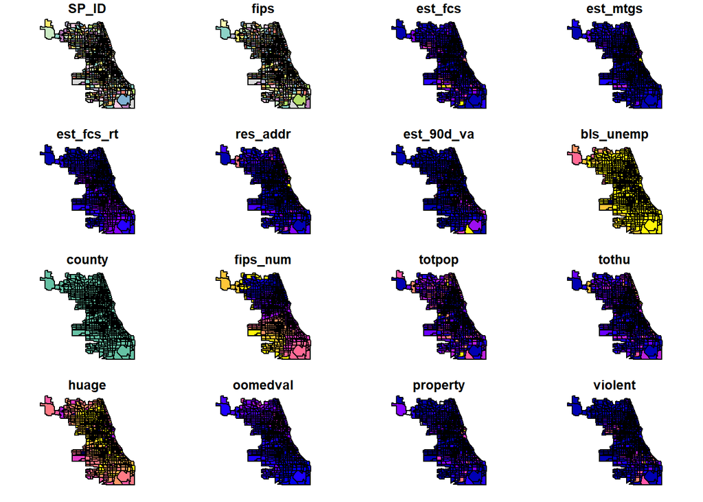

```r
plot(chi.poly, max.plot= 16)
```

```r
#makes plot images of all variables in chi.poly
```

```r
##install.packages('leaflet')

library(leaflet)

leaflet(chi.poly) %>%
  addPolygons(stroke = FALSE, fillOpacity = 0.5, smoothFactor = 0.5) %>%
  addTiles() #adds a map tile, the default is OpenStreetMap
```

[interactive chart not shown]

```r
require(RColorBrewer)

pal <- colorQuantile(
  palette  = "OrRd",
  domain = chi.poly$violent)

map <- leaflet(chi.poly)

map %>%
  addPolygons(stroke = FALSE, smoothFactor = 0.2, fillOpacity = 1,
              color = ~pal(violent)) %>% addTiles()
```

[interactive chart not shown]

We can take the data from our shapefile and do statistical analysis with it too.

We can start by taking a standard OLS regression by looking at the effect of unemployment and percent of mortgages in the area being foreclosed on violence in Chicago.

est_fcs_rt = the percentage of total homes in the census tract that are foreclosed bls_unemp = the unemployment rate as estimated by the Bureau of Labor Statistics in June 2008 violent = number of violent crimes reported between Jan. 2007 through December 2008

To run a standard OLS regression (in this case multiple linear regression since we have more than one explanatory variable), we use the lm command in R.

The dependent variable goes on the left hand side inside a (, and a ~ separates the dependent from the independent variables. If you have more than one independent/explanatory variable, separate them with a +. The data is the data included in our polygon shapefile, chi.poly.

# OLS

```r
chi.ols<-lm(chi.poly$violent~chi.poly$est_fcs_rt+chi.poly$bls_unemp, data=chi.poly$data)

summary(chi.ols)
```

```
##
## Call:
## lm(formula = chi.poly$violent ~ chi.poly$est_fcs_rt + chi.poly$bls_unemp,
##     data = chi.poly$data)
##
## Residuals:
##     Min      1Q  Median      3Q     Max
## -892.02  -77.02  -23.73   41.90 1238.22
##
## Coefficients:
##                     Estimate Std. Error t value Pr(>|t|)
## (Intercept)          -18.627     45.366  -0.411    0.681
## chi.poly$est_fcs_rt   28.298      1.435  19.720   <2e-16 ***
## chi.poly$bls_unemp    -0.308      5.770  -0.053    0.957
## ---
## Signif. codes:  0 '***' 0.001 '**' 0.01 '*' 0.05 '.' 0.1 ' ' 1
##
## Residual standard error: 157.3 on 894 degrees of freedom
## Multiple R-squared:  0.3141, Adjusted R-squared:  0.3126
## F-statistic: 204.7 on 2 and 894 DF,  p-value: < 2.2e-16
```

Interpret the coefficients. Is there a potential issue with using OLS in spatial analysis?

# Identifying Spatial Dependence/Autocorrelation

We can use the spdep package to estimate spatial dependence using the queen criterion of contiguity. If we use queen=TRUE, then it will use queen criterion. If we use queen=FALSE, we will have rook criterion.

```
##   format width height colorspace matte filesize density
## 1   JPEG   846    596       sRGB FALSE    60534   72x72
```

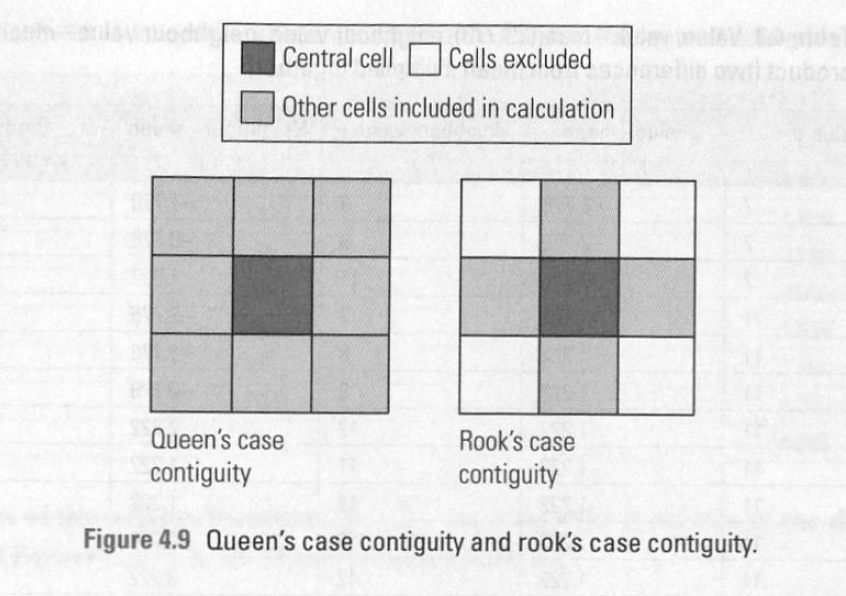

```r
library(magick)
image_url <- "https://i.stack.imgur.com/CWIHi.jpg"
pic <- image_read(image_url)
print(pic)
```

Queen criterion looks at polygons in all directions adjacent, while rook criterion only looks directly in front of or to the side. See image above.

If we believe there is spatial autocorrelation in our data, we can determine the extent of it by assigning weights to the autocorrelation using our contiguity.

```r
library(spdep)
list.queen<-poly2nb(chi.poly, queen=TRUE)
W<-nb2listw(list.queen, style="W", zero.policy=TRUE)
W
```

```
## Characteristics of weights list object:
## Neighbour list object:
## Number of regions: 897
## Number of nonzero links: 6140
## Percentage nonzero weights: 0.7631036
## Average number of links: 6.845039
##
## Weights style: W
## Weights constants summary:
##     n     nn  S0       S1       S2
## W 897 804609 897 274.4893 3640.864
```

W represents our weights.

We can plot our spatial autocorrelation on our polygon to see if we have our neighbors all connected.

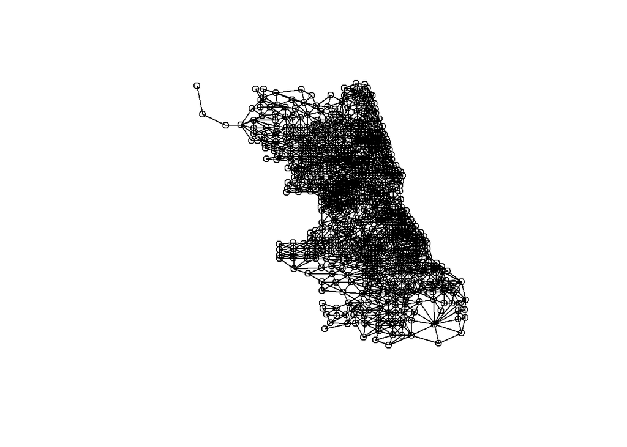

```r
plot(W,chi.poly$geometry)
```

## Spatial Regression Models

The following lists types of regression models that we can use to correct our models for this spatial autocorrelation to try and get more accurate measures of the marginal effects (if any) of our explanatory variables on the variable of concern (violent crime in Chicago).

# The Spatial Autoregression Model (SARs):

Spatial lag dependence in a regression setting can be modeled similar to an autoregressive process in time series.

$$y= \rho Wy+ X \beta + \epsilon$$
The presence of the term
$$Wy$$
induces a nonzero correlation with the error term, similar to the presence of an endogenous variable, but different from the time series context. Contrary to time series,
$$[Wy]i$$
is always correlated with
$$ϵi$$
irrespective of the structure of the errors. This implies that OLS estimates in the non spatial model will be biased and inconsistent. (Anselin and Bera (1998))

# Spatial Error Models (SEMs)

Another way to model spatial autocorrelation in a regression model is to specify the autoregressive process in the error term:

$$y= X \beta + \epsilon$$
with
$$\epsilon = \lambda W \epsilon + u$$

If this is the “true” form of spatial dependence OLS estimates will be unbiased but inefficient.

## Testing for Spatial Autocorrelation

There are multiple tests for testing the presence of spatial autocorrelation. We will test using two options: Moran’s I test and LaGrangian Multiplier tests.

# Moran Test

Moran’s I test was originally developed as a two-dimensional analog of Durbin-Watson’s test
$$\begin{equation}
I = \left( \frac{e'We}{e'e} \right)
\end{equation}$$

where
$$e=y−Xβ$$
is a vector of OLS residuals
$$\beta= (X'X)^{-1} X'y$$
,
$$W$$
is the row standardized spatial weights matrix. (For more detail see Anselin and Bera (1998))

To perform a Moran test on our data we need two inputs, an lm regression object (estimated in the OLS section) and the spatial weight matrix.

Let’s try running a Moran’s test.

```r
moran.lm<-lm.morantest(chi.ols, W, alternative="two.sided")
print(moran.lm)
```

```
##
##  Global Moran I for regression residuals
##
## data:
## model: lm(formula = chi.poly$violent ~ chi.poly$est_fcs_rt +
## chi.poly$bls_unemp, data = chi.poly$data)
## weights: W
##
## Moran I statistic standard deviate = 11.785, p-value < 2.2e-16
## alternative hypothesis: two.sided
## sample estimates:
## Observed Moran I      Expectation         Variance
##     0.2142252370    -0.0020099108     0.0003366648
```

The computation of the statistic is relative to a given choice of the spatial weights W. Different specifications of the weights matrix will give different results. On your own (results not shown in this lab) try again using the rook contiguity to see how your results change.

# Lagrange Multiplier Test

A nice feature of Moran’s I test is that it has high power against a wide range of alternatives (Anselin and Bera (1998)). However, it does not guide us in the selection of alternative models. On the other hand, Lagrange Multiplier test specifies the alternative hypothesis which will help us with the task. The LM tests for spatial dependence are included in the lm.LMtests function and include as alternatives the presence of a spatial lag and the presence of a spatial lag in the error term. Both tests, as well as their robust forms are included in the lm.LMtests function. To call them we use the option test=“all”. Again, a regression object and a spatial list (the spatial weight matrix) object must be passed as arguments:

Let’s try a LaGrangian Multiplier test

```r
LM<-lm.LMtests(chi.ols, W, test="all")
print(LM)
```

```
##
##  Lagrange multiplier diagnostics for spatial dependence
##
## data:
## model: lm(formula = chi.poly$violent ~ chi.poly$est_fcs_rt +
## chi.poly$bls_unemp, data = chi.poly$data)
## weights: W
##
## LMerr = 134.52, df = 1, p-value < 2.2e-16
##
##
##  Lagrange multiplier diagnostics for spatial dependence
##
## data:
## model: lm(formula = chi.poly$violent ~ chi.poly$est_fcs_rt +
## chi.poly$bls_unemp, data = chi.poly$data)
## weights: W
##
## LMlag = 182.18, df = 1, p-value < 2.2e-16
##
##
##  Lagrange multiplier diagnostics for spatial dependence
##
## data:
## model: lm(formula = chi.poly$violent ~ chi.poly$est_fcs_rt +
## chi.poly$bls_unemp, data = chi.poly$data)
## weights: W
##
## RLMerr = 0.00066762, df = 1, p-value = 0.9794
##
##
##  Lagrange multiplier diagnostics for spatial dependence
##
## data:
## model: lm(formula = chi.poly$violent ~ chi.poly$est_fcs_rt +
## chi.poly$bls_unemp, data = chi.poly$data)
## weights: W
##
## RLMlag = 47.653, df = 1, p-value = 5.089e-12
##
##
##  Lagrange multiplier diagnostics for spatial dependence
##
## data:
## model: lm(formula = chi.poly$violent ~ chi.poly$est_fcs_rt +
## chi.poly$bls_unemp, data = chi.poly$data)
## weights: W
##
## SARMA = 182.18, df = 2, p-value < 2.2e-16
```

Since LMerr and LMlag are both statistically significant different from zero, we need to look at their robust counterparts. These robust counterparts are actually robust to the presence of the other “type” of autocorrelation. The robust version of the tests suggest that the lag model is the more likely alternative.

Now let’s try to run our regression models.

The estimation of the SAR model can be approached in two ways. One way is to assume normality of the error term and use maximum likelihood. This is achieved in R with the function lagsarlm.

Running a SAR model

```r
sar.chi<-lagsarlm(chi.poly$violent~chi.poly$est_fcs_rt+chi.poly$bls_unemp, data=chi.poly, W)
summary(sar.chi)
```

```
##
## Call:
## lagsarlm(formula = chi.poly$violent ~ chi.poly$est_fcs_rt + chi.poly$bls_unemp,
##     data = chi.poly, listw = W)
##
## Residuals:
##      Min       1Q   Median       3Q      Max
## -519.127  -65.003  -15.226   36.423 1184.193
##
## Type: lag
## Coefficients: (asymptotic standard errors)
##                     Estimate Std. Error z value Pr(>|z|)
## (Intercept)         -93.7885    41.3162  -2.270  0.02321
## chi.poly$est_fcs_rt  15.6822     1.5600  10.053  < 2e-16
## chi.poly$bls_unemp    8.8949     5.2447   1.696  0.08989
##
## Rho: 0.49037, LR test value: 141.33, p-value: < 2.22e-16
## Asymptotic standard error: 0.039524
##     z-value: 12.407, p-value: < 2.22e-16
## Wald statistic: 153.93, p-value: < 2.22e-16
##
## Log likelihood: -5738.047 for lag model
## ML residual variance (sigma squared): 20200, (sigma: 142.13)
## Number of observations: 897
## Number of parameters estimated: 5
## AIC: 11486, (AIC for lm: 11625)
## LM test for residual autocorrelation
## test value: 8.1464, p-value: 0.0043146
```

Another way is to use 2SLS using the function stsls. This is basically running the model with instruments.

Running a 2SLS model

```r
sar2sls.chi<-stsls(chi.poly$violent~chi.poly$est_fcs_rt+chi.poly$bls_unemp, data=chi.poly, W)
summary(sar2sls.chi)
```

```
##
## Call:
## stsls(formula = chi.poly$violent ~ chi.poly$est_fcs_rt + chi.poly$bls_unemp,
##     data = chi.poly, listw = W)
##
## Residuals:
##      Min       1Q   Median       3Q      Max
## -472.703  -61.955  -12.668   36.795 1168.899
##
## Coefficients:
##                        Estimate  Std. Error t value  Pr(>|t|)
## Rho                    0.629161    0.082777  7.6007 2.953e-14
## (Intercept)         -115.062608   42.648091 -2.6980  0.006977
## chi.poly$est_fcs_rt   12.111383    2.488729  4.8665 1.136e-06
## chi.poly$bls_unemp    11.499706    5.406927  2.1268  0.033433
##
## Residual variance (sigma squared): 19943, (sigma: 141.22)
```

We then can compare the residuals of the OLS regression to the residuals of the spatial autoregressive model. To access the residuals for the OLS model and the SAR model use the following code:

Compare residuals of OLS and Spatial autocorrelative model

```r
chi.poly$chi.ols.res<-resid(chi.ols) #residuals ols

chi.poly$chi.sar.res<-resid(sar.chi) #residual sar
```

Mapping the variation in our residuals between OLS and Spatial autocorrelative Model

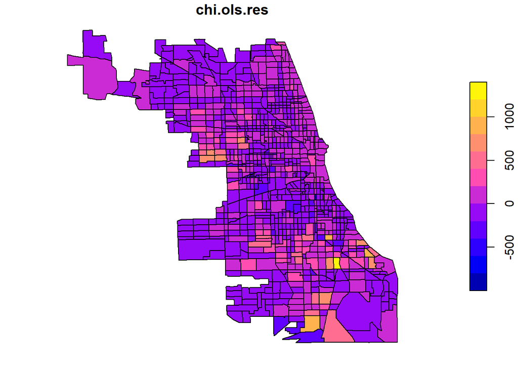

```r
colurrr <- brewer.pal(11, "RdBu")
plot(chi.poly["chi.ols.res"])
```

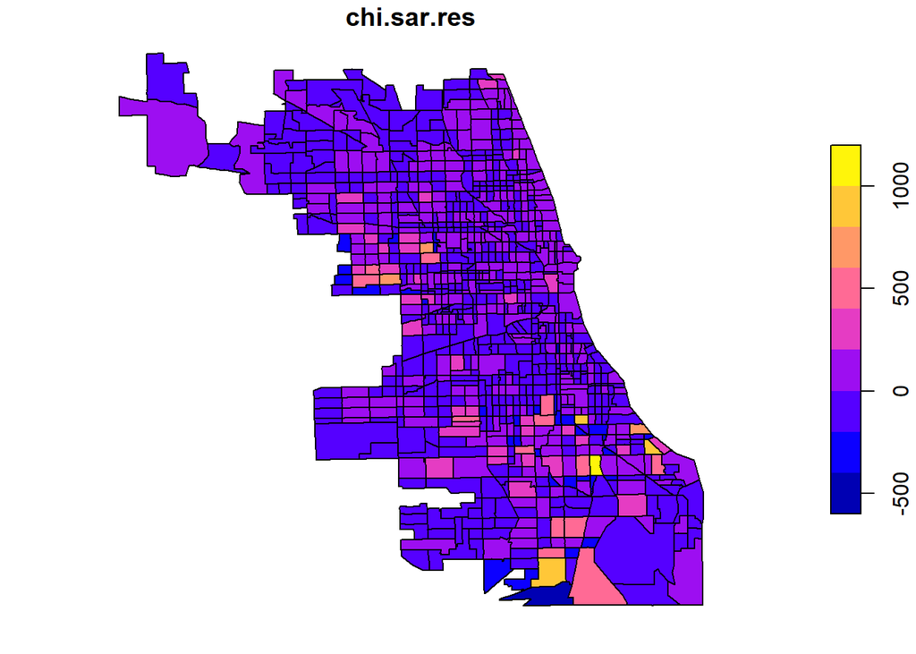

```r
plot(chi.poly["chi.sar.res"])
```

# Measuring Impacts

Note that the presence of the spatial weights matrix makes marginal effects richer and slightly more complicated than in the “traditional” OLS model. We’ll have three impact measures suggested by Pace and LeSage (2009) and is done in R with the function impacts

Measuring Marginal impacts

```r
impacts(sar.chi, listw=W)
```

```
## Impact measures (lag, exact):
##                        Direct  Indirect    Total
## chi.poly$est_fcs_rt 16.434479 14.336896 30.77137
## chi.poly$bls_unemp   9.321585  8.131842 17.45343
```

The direct impact refers to average total impact of a change of an independent variable on the dependent fore each observation, i.e.,
$$n^{-1}\sum_{i=1}^{n}\frac{\partial E(y_{i})}{\partial X_{i}}$$
, the indirect impact which is the sum of the impact produced on one single observation by all other observations and the impact of one observation on all the other. The total is the summation of the two

Let’s try estimating the spatial error model now. There are two approaches.

First, we can use Maximum Likelihood as before, with the function errorsarlm.

Spatial Error Model using Maximum Likelihood

```r
errorsalm.chi<-errorsarlm(chi.poly$violent~chi.poly$est_fcs_rt+chi.poly$bls_unemp, data=chi.poly, W)
summary(errorsalm.chi)
```

```
##
## Call:errorsarlm(formula = chi.poly$violent ~ chi.poly$est_fcs_rt +
##     chi.poly$bls_unemp, data = chi.poly, listw = W)
##
## Residuals:
##      Min       1Q   Median       3Q      Max
## -650.506  -64.355  -22.646   35.461 1206.346
##
## Type: error
## Coefficients: (asymptotic standard errors)
##                     Estimate Std. Error z value Pr(>|z|)
## (Intercept)          -1.2624    43.0509 -0.0293   0.9766
## chi.poly$est_fcs_rt  19.4620     1.9450 10.0062   <2e-16
## chi.poly$bls_unemp    4.0380     5.5134  0.7324   0.4639
##
## Lambda: 0.52056, LR test value: 109.68, p-value: < 2.22e-16
## Asymptotic standard error: 0.042291
##     z-value: 12.309, p-value: < 2.22e-16
## Wald statistic: 151.51, p-value: < 2.22e-16
##
## Log likelihood: -5753.875 for error model
## ML residual variance (sigma squared): 20796, (sigma: 144.21)
## Number of observations: 897
## Number of parameters estimated: 5
## AIC: 11518, (AIC for lm: 11625)
```

We can once again plot our residuals.

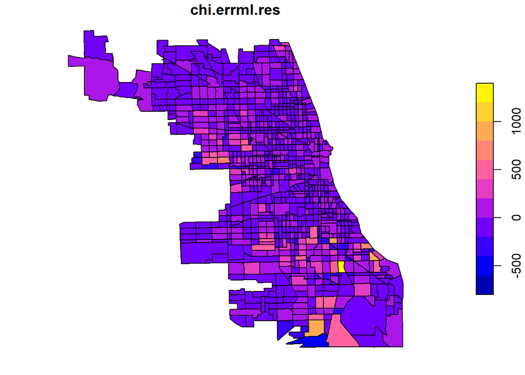

```r
chi.poly$chi.errml.res<-resid(errorsalm.chi) #residual sem
plot(chi.poly["chi.errml.res"])
```

A second approach is use Feasible Generalized Least Squares (GLS) with the function GMerrorsar. The function is:

FGLS (Feasible Generalized Least Squares)

```r
fgls.chi<-GMerrorsar(chi.poly$violent~chi.poly$est_fcs_rt+chi.poly$bls_unemp, data=chi.poly, W)
summary(fgls.chi)
```

```
##
## Call:GMerrorsar(formula = chi.poly$violent ~ chi.poly$est_fcs_rt +
##     chi.poly$bls_unemp, data = chi.poly, listw = W)
##
## Residuals:
##      Min       1Q   Median       3Q      Max
## -697.623  -76.205  -33.292   44.053 1271.737
##
## Type: GM SAR estimator
## Coefficients: (GM standard errors)
##                     Estimate Std. Error z value Pr(>|z|)
## (Intercept)          -1.8587    43.5671 -0.0427   0.9660
## chi.poly$est_fcs_rt  21.1757     1.8752 11.2925   <2e-16
## chi.poly$bls_unemp    2.9037     5.5869  0.5197   0.6032
##
## Lambda: 0.44789 (standard error): 0.11067 (z-value): 4.0473
## Residual variance (sigma squared): 21515, (sigma: 146.68)
## GM argmin sigma squared: 21607
## Number of observations: 897
## Number of parameters estimated: 5
```

We can import our residuals into an interactive map to be able to match our census tracts and residual values with the locations they represent for easier connection.

```r
pal2 <- colorQuantile(
  palette  = "GnBu",
  domain = chi.poly$chi.sar.res)

map2 <- leaflet(chi.poly)

map2 %>%
  addPolygons(stroke = FALSE, smoothFactor = 0.2, fillOpacity = 0.7,
              color = ~pal2(chi.sar.res)) %>% addTiles()
```

[interactive chart not shown]